# L04 ggplot III

Data Visualization (STAT 302)

Martha Eichlersmith

2020-04-19

## Overview

The goal of this lab is to continue the process of unlocking the power of `ggplot2` through constructing and experimenting with a few basic plots.

**Load Packages:** `tidyverse`, `gridExtra`, `ggrepel`

```r
# Load package(s)
suppressPackageStartupMessages(library(tidyverse))
suppressPackageStartupMessages(library(gridExtra))
suppressPackageStartupMessages(library(ggrepel))

knitr::opts_chunk$set(dpi = 300)
```

## Datasets

We’ll be using data from the `blue_jays.rda`, `tech_stocks.rda`, `corruption.rda`, and `cdc.txt` datasets which are already in the `/data` subdirectory in our **data_vis_labs** project.

```r
# Load datasets
load(file = "data/blue_jays.rda")
load(file = "data/tech_stocks.rda")
load(file = "data/corruption.rda")

# Read in the cdc dataset
cdc <- read_delim(
  file = "data/cdc.txt"
  , delim = "|"
  ) %>%
  mutate(genhlth = factor(genhlth,
    levels = c("excellent", "very good", "good", "fair", "poor")
  ))
```

## Exercises

### Exercise 1

The following plot uses the `blue_jays.rda` dataset.

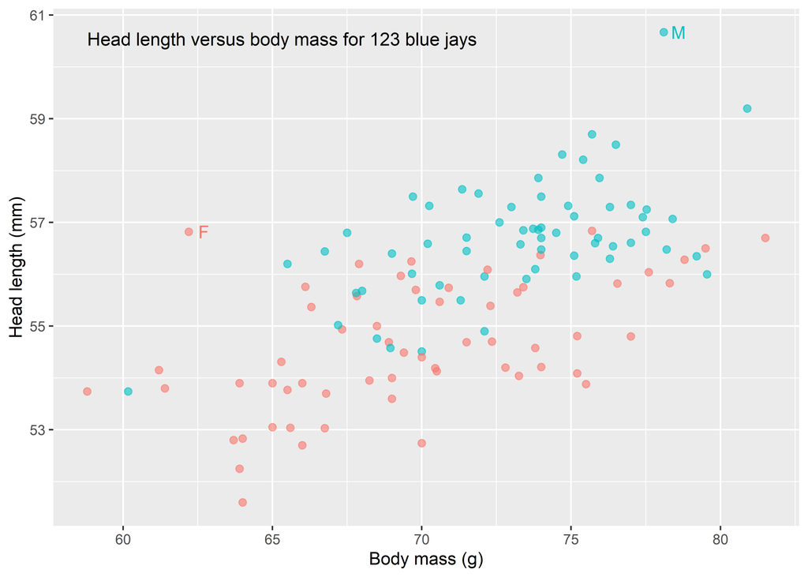

```r
#create caption that automatically grabs number of blue jays
caption <- paste("Head length versus body mass for", nrow(blue_jays), "blue jays")

#add string wrap
#will break the caption into multiple lines if longer than 40 characters
# '\n' is the line break code
caption_print <- paste(strwrap(caption, 40), collapse ="\n")

#create data set for top head size for each sex
topHead <- blue_jays %>%
  #arrange largest to smallest
  arrange(desc(Head)) %>%
  # group by sex
  group_by(KnownSex) %>%
  #take the top 2 head sizes  for each group
  top_n(n = 2, wt = Head)

#'M' label will be put on the top male head size
#'F' label will be put on the 2nd top female head size
Labels <- topHead[c(1,4),]

#ANOTHER OPTIONS: lable dataframe
#search by BirdID
Labels_anotheroption <- blue_jays  %>%
  #select specific bird where you want the labels
  filter(BirdID %in% c("1142-05914", "702-90567"))

#get range for x and y variables
xrng <- range(blue_jays$Mass)
yrng <- range(blue_jays$Head)

#head length by body mass
ggplot(blue_jays, aes(Mass, Head, color = KnownSex)) +
  geom_point(alpha = 0.6, size = 2) +
  annotate(
     "text"
    #put text in the top left corner of plot
    , x = xrng[1], y = yrng[2]
    #label is the caption already create
    , label = caption
    #left justify
    , hjust = 0
    # bottom justify
    , vjust = 1
    #size the font
    , size = 4
    ) +
  xlab("Body mass (g)") +
  ylab("Head length (mm)") +
  #remove all legends; to remove just one legend put show.legend = FALSE into geom
  theme(legend.position = "none") +
  # add labels
  geom_text(
    #use labels data set
      data = Labels
    , aes(label = KnownSex)
    #nudget labels to the right
    , nudge_x = 0.5
    )
```

### Exercise 2

The following plots use the `tech_stocks` dataset.

#### Plot 1

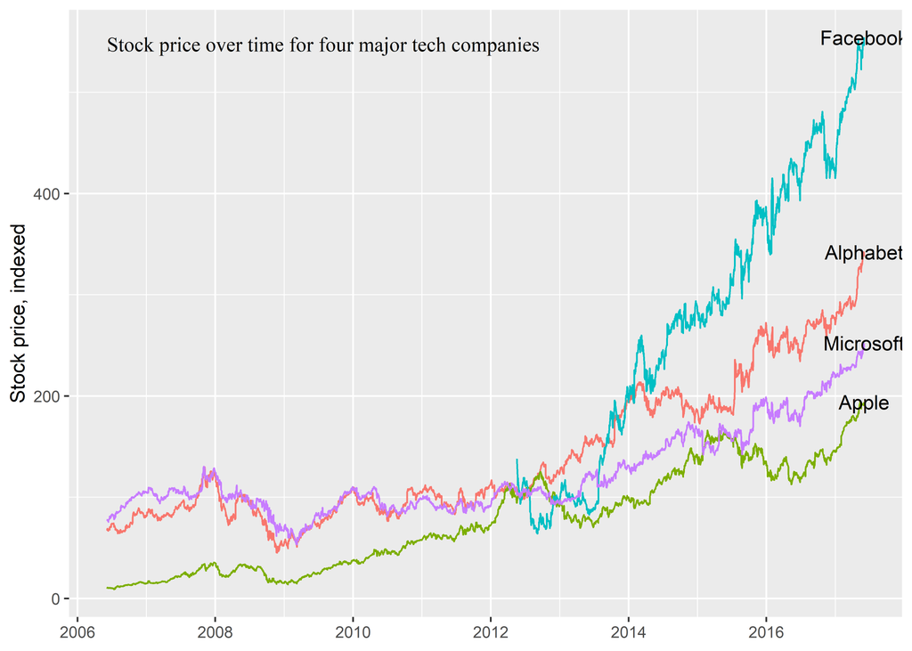

```r
#create caption
caption <- paste("Stock price over time for four major tech companies")

#add string wrap
#will break the caption into multiple lines if longer than 40 characters
# '\n' is the line break code
caption_print <- paste(strwrap(caption, 40), collapse = "\n")

#create labels df with most recent stock values
Labels <- tech_stocks %>%
  ungroup() %>%
  #order by date
  arrange(desc(date)) %>%
  # return distinct company
  distinct(company
           #keep all variables not just company
           , .keep_all = TRUE
           )

#get range for x and y variables
xrng <- range(tech_stocks$date)
yrng <- range(tech_stocks$price_indexed)

tech_stocks <- tech_stocks %>%
  ungroup()

#stock price by date
ggplot(tech_stocks, aes(date, price_indexed)) +
  #put color in geom_line so labels are not colored
  geom_line(aes(color = company)) +
  # remove all legends
  theme(legend.position  =  "none") +
  #remove x label
  xlab(NULL) +
  ylab("Stock price, indexed") +
  annotate(
    "text"
    #put text in the top left corner of plot
    , x = xrng[1], y = yrng[2]
     #label is the caption already create
    , label = caption
    #left justify
    , hjust = 0
    # bottom justify
    , vjust = 1
    #use serif font
    , family = "serif"
    #size the font
    , size = 4
    ) +
  #add company labels to the most recent stock price
  geom_text(data = Labels, aes(label = company))
```

#### Plot 2

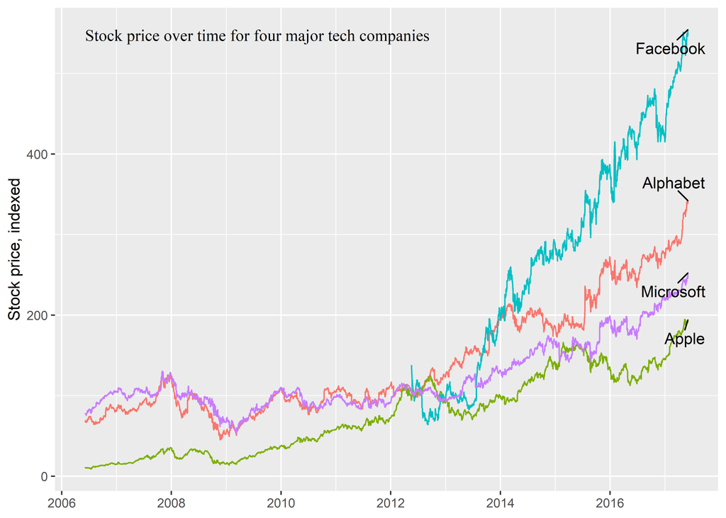

```r
#stock price by date
ggplot(tech_stocks, aes(date, price_indexed)) +
  #put color in geom_line so labels are not colored
  geom_line(aes(color = company)) +
  # remove all legends
  theme(legend.position  =  "none") +
  #remove x label
  xlab(NULL) +
  ylab("Stock price, indexed") +
  annotate(
    "text"
    #put text in the top left corner of plot
    , x = xrng[1], y = yrng[2]
     #label is the caption already create
    , label = caption
    #left justify
    , hjust = 0
    # bottom justify
    , vjust = 1
    #use serif font
    , family = "serif"
    #size the font
    , size = 4
    ) +
  #add company labels to the most recent stock price
  geom_text_repel(
      data = Labels
    , aes(label = company)
    #padding around label
    , box.padding = 0.6
    , min.segment.length = 0
    #right align text (so doesn't go off the plot)
    , hjust = 1
    #set seed for repel iterations
    , seed = 9876
    )
```

### Exercise 3

The following plot uses the `corruption.rda` dataset.

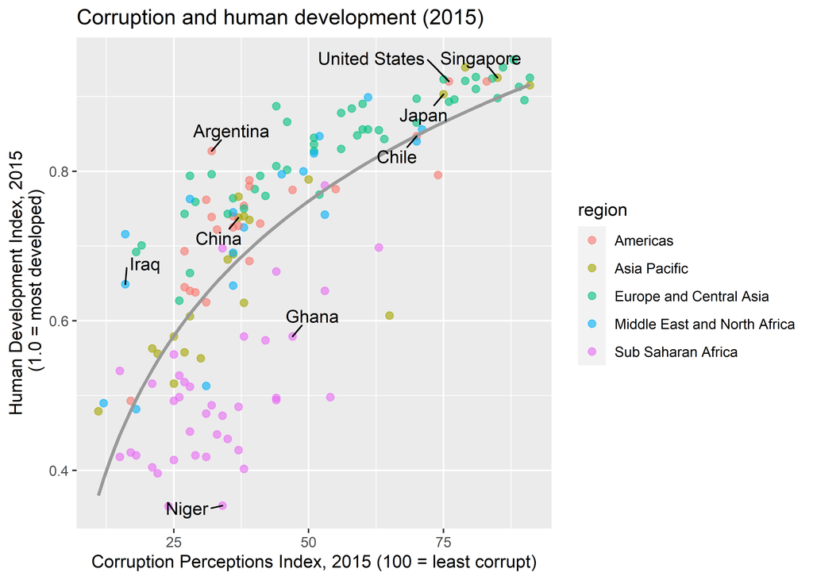

```r
#look at 2015 data
corruption_2015 <- corruption %>%
  #remove countries that don't have cpi or hdi values
  drop_na(cpi, hdi) %>%
  #only look at 2015 data
  filter(year == 2015)

#the contries we want to label
CountriesToLabel <- c(
    "Niger"
  , "Iraq"
  , "China"
  , "Ghana"
  , "Argentina"
  , "Chile"
  , "Japan"
  , "United States"
  , "Singapore"
  )

#create labels data frame
Labels <- corruption_2015 %>%
  #only select specific countries already specified
  filter( country %in% CountriesToLabel)

#hdi by cpi
ggplot(corruption_2015, aes(cpi, hdi)) +
  #put color in geom_line so labels are not colored, color by geom
  geom_point(aes(color = region), alpha = 0.6, size = 2) +
    geom_smooth(
        method = "lm"
      # use log(x) when modeling
      , formula =  y~log(x)
      # specify grey color for line
      , color = "grey60"
      # remove standard error bars
      , se = FALSE
      ) +
  xlab("Corruption Perceptions Index, 2015 (100 = least corrupt)") +
  #add y label; '\n' creates line break
  ylab("Human Development Index, 2015\n (1.0 = most developed)") +
  #add title
  ggtitle("Corruption and human development (2015)")+
  #add labels to specific countries
  geom_text_repel(
      data = Labels
    , aes(label = country)
    #set seed for repel iterations
    , seed  =  9876
    , box.padding  =  0.6
    , min.segment.length = 0
    )
```

### Exercise 4

The next plot uses the `cdc` dataset.

Using Bilbo Baggins’ responses below to the CDC BRSFF questions, add Bilbo’s data point as a transparent (0.5) solid red circle of size 4 to a scatterplot of `weight` by `height` with transparent (0.1) solid blue circles of size 2 as the plotting characters. In addition, label the point with his name in red. Left justify and rotate the label so it reads vertically from bottom to top — shift it up by 10 pounds too. Plot should use appropriately formatted axis labels. Remember that the default shape is a solid circle.

- `genhlth` - How would you rate your general health? **fair**
- `exerany` - Have you exercised in the past month? **1=yes**
- `hlthplan` - Do you have some form of health coverage? **0=no**
- `smoke100` - Have you smoked at least 100 cigarettes in your life time? **1=yes**
- `height` - height in inches: **46**
- `weight` - weight in pounds: **120**
- `wtdesire` - weight desired in pounds: **120**
- `age` - in years: **45**
- `gender` - m for males and f for females: **m**

*Hint:* Create a new dataset (maybe call it `bilbo` or `bilbo_baggins`) using either `data.frame()` (base R - example in book) or `tibble()` (tidyverse - see help documentation for the function). Make sure to use variable names that exactly match `cdc`’s variable names

[figure not shown]

```r
bilbo <- tibble(
  genhlth = "fair",
  exerancy = 1,
  hlthplan = 0,
  smoke100 = 1,
  height = 46,
  weight = 120,
  wtdesire = 120,
  age = 45,
  gender = "m"
)

ggplot(cdc, aes(height, weight)) +
  geom_point(alpha = 0.1, color = "blue", size = 2) +
  ggtitle("Bilbo Baggins is on the small side") +
  labs(
      x = "Height (inches)"
    , y = "Weight (pounds)"
    , subtitle = "CDC Data: Weight by Height"
  ) +
  #add Bilbo Baggins special red point onto graph
  geom_point(data = bilbo, color = "red", size = 4, alpha = 0.5) +
  #add sing label
  geom_text(
      data = bilbo
    , aes(label = "Bilbo Baggins")
    , color = "red"
    #left justify label
    , hjust = 0
    #rotate label
    , angle = 90
    #nudge label up 10 pounds
    , nudge_y = 10
    )
```